# Final Paper

STOR 320.02 Group 5

April 28, 2023

# INTRODUCTION

After the recent COVID-19 pandemic, several businesses and the informal economy were poorly affected. Amidst the chaos, the pandemic led to a massive surge in the world of social media and social media dependency, more specifically, the film industry. Countries that were ‘pandemic hotspots’ began to restrict movie theaters and as a result, the film industries suffered billions of dollars of losses. Consequently, in 2021, the Netflix franchise had approximately 222 million subscribers as they added 18.2 million, roughly half the number that had subscribed in 2020. Many other streaming companies including Disney+, HBO Max, and Hulu sparked competition within themselves as they began to grow their respective brands to increase their network of subscribers.

In our initial data exploration, we examined a dataset of Netflix TV shows and movies including their respective IMDB scores, TMDB scores, director(s), genre(s), and runtime. We structured our primary questions around the relationships between the distinct variables. After further exploring the data in our exploratory data analysis, we implemented another data set containing the revenue values for several movies. The combination of these data sets led us to finalize our two questions in relation to what variables most positively influence revenue produced and the average of IMDB and TMDB score for movies only.

Question 1: What variable(s) of movies are the best indicators of a strong IMDB/TMDB average score?

Question 2: Which variable(s) are the best predictors for the total revenue a movie produces?

For the first question, we delved into which variables from our data set would yield a low p-value, when compared and correlated with the average IMDB/TMDB score of a movie. We believe that through the exploration of this question, [we wondered] if we could use the strongest parameters to predict what factors that future film industries can alter in order to receive a higher IMDB/TMDB average score. Our second question explores a similar concept of exploring different variables and seeing which strongly correlate with generating large amounts of revenue. In accordance with our first question, the second question will add to the idea of what variables future film industries need to focus on in order to generate more revenue. We aim to use our exploration and data analysis of these datasets to answer our overarching question of what factors go into producing a ‘hit movie’. With the [comeback] rise of the film industry, it could provide beneficial for film producers to [know] what factors strongest influence the success of their movies.

# DATA

Our data consists of multiple datasets that we merged. The first dataset is the “TMDB 10000 Movies Dataset” from Kaggle. The data was sourced directly from TMDB (The Movie Database) APIs and is updated annually. The following dataset that was used is from Daniel Grijvala on GitHub. The “Movie Industry” dataset contains 6820 movies (220 movies per year, 1986-2016) which were scrapped from the IMDb (The Internet Movie Database) website. Additional data we utilized in our data cleaning was “Top 100 Actors” and “Top 100 Actresses” from the IMDb website. We joined these two datasets to ensure we had enough variables to create our prediction models. After merging the datasets, we had 4,353 entries and 22 columns. The reason for combining the datasets is mainly because of the different variables in each dataset that we need for our prediction models.

In our data, each row represents a singular movie. Alongside the name of a film, we have rating, genre, release_date, year, runtime, director, star, topdirector, starbin, country, avg_imdb_tmdb_score, votes, imdb_score, imdb_votes, tmdb_score, tmdb_votecount, budget, and revenue. After filtering missing data and cleaning the dataset, we ended up with 19 variables that we deemed were more applicable to our analysis. Below is a table that displays the essential variables concluded after cleaning our data:

| Name | Rating | Genre | Year | Runtime | Country | Budget | Top Director | Top Actor | Average IMDB TMDB Score | Votes | Revenue |
| --- | --- | --- | --- | --- | --- | --- | --- | --- | --- | --- | --- |
| The Shining | R | Drama | 1980 | 146 | United Kingdom | 19.00 | 0 | 0 | 8.30 | 942465 | 47.00 |
| The Blue Lagoon | R | Adventure | 1980 | 104 | United States | 4.50 | 0 | 0 | 6.00 | 66579 | 58.85 |
| Airplane! | PG | Comedy | 1980 | 88 | United States | 3.50 | 0 | 0 | 7.50 | 224844 | 83.45 |
| Caddyshack | R | Comedy | 1980 | 98 | United States | 6.00 | 0 | 0 | 6.95 | 108965 | 39.85 |
| Friday the 13th | R | Horror | 1980 | 95 | United States | 0.55 | 0 | 0 | 6.40 | 125427 | 39.75 |
| The Blues Brothers | R | Action | 1980 | 133 | United States | 27.00 | 0 | 0 | 7.85 | 191649 | 115.23 |

As you can see in our table above, IMDB ratings are constructed from registered users who can vote (on a scale of 1 to 10) on every released title in the database. These individual votes, represented as imdb_votes in our original data, are then aggregated and summarized as a singular IMDB rating, visible on the film’s main page. As you can see, we averaged our imdb_score and tmdb_score variables to create one variable called “avg_imdb_tmdb_scores,” where we consider above-average films >7.1 and a below-average film would be awarded a 6.15 or below. We totaled the imdb_votes and tmdb_votecount into one variable named “votes.” TMDB scores are gathered similarly; the only difference is that IMDB is older and has more data. Our main reason for averaging the IMDB and TMDB scores is because of collinearity which would undermine the prediction of the popularity and revenue of a film. Two other variables created are “starbin” and “topdirector.” We used a binary number system to indicate the top actors and actresses (“starbin”) and top 10 directors (“topdirector”) to show how top stars and directors affect our prediction models.

To explore the data, we decided to look at how average revenue is different among each genre. We also acknowledge that different years can have very different trends among which genres were more popular and produced more high revenue movies. Therefore, we decided to depict this relationship between revenue, genre, and year with an animation. Since we wanted to also examine the average IMDB/TMDB score in our questions, we made another animation which looked at the average IMDB/TMDB score as the response.

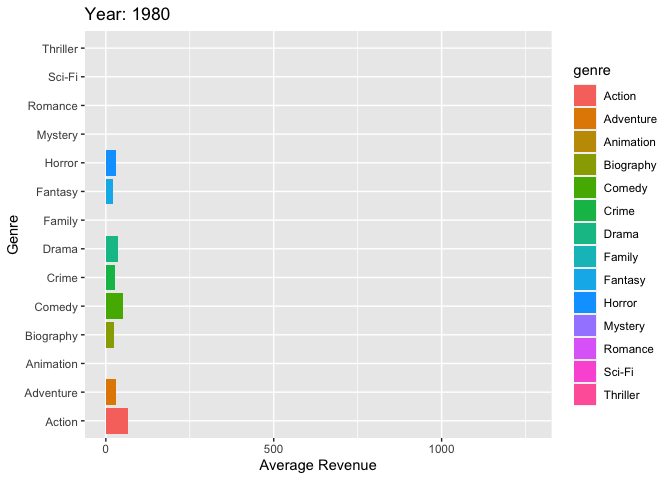

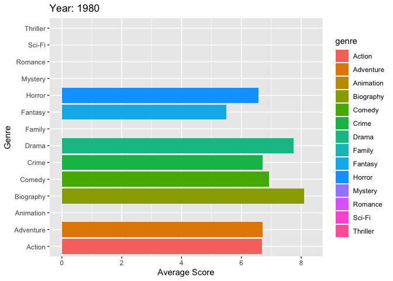

The figures above focus on the two key variables (avg_imdb_tmdb_score and revenue) needed for our analysis. The purpose of the figure is to continue our exploration based on the correlation between these two variables, which can give us insight into what we might conclude from our final analysis.

# RESULTS

To assess the presence of multicollinearity in the movie dataset, we calculated the variance inflation factor (VIF) for each independent variable. We wanted to avoid a VIF value of greater than 5, which would indicate a significant problem with multicollinearity. In a full model, the VIF of imdb_score and tmdb_score was 6.38, which is expected because they represent two different sources for the same criteria. This justifies our decision to construct an average score between these 2 sources in order to use in our models. The VIF values for our chosen variables to consider were all below 5, with the highest value being 3.2. This means that the independent variables in the dataset are not highly correlated with each other, and that the estimated coefficients are not biased due to multicollinearity.

To answer our first question, “What variable(s) of movies are the best indicators of a strong IMDB/TMDB average score?” we had to alter some variables, such as the creation of “avg_imdb_tmdb_score” and the “profit” variable which is the difference between “revenue” and “budget.” To begin our analysis, we checked for collinearity between our numerical variables to avoid increasing errors when creating our models. We discovered that “revenue” and “budget” have a high correlation of 0.73; therefore, we created a new variable, “profit.” To create our models, we decided to use a subset selection where we found that “votes” is the best numerical value to use for prediction if one variable is to be used. Then, we tried several polynomial models with “votes” as the only variable. In order to find the Mean Absolute Error and Root Mean Square Error, we used a 10-fold cross-validation to estimate how our model is expected to perform. Our results stated that the third-degree polynomial yielded the lowest Mean Absolute Error (MAE) of 0.4740539, whereas the fifth-degree polynomial exhibited the lowest Root Mean Square Error (RMSE) of 0.5796674.

Subsequently, we created the models (model 1 to model 4) for the numerical subsets. We started by using the 10-fold cross-validation for the subsets. Since the model with only “votes” yielded the best prediction, we created two additional models with a fourth and fifth polynomial degree of votes. With these models, model 6 (the fifth polynomial degree) had the lowest Root Mean Square Error of 0.5401709 and Mean Absolute Error of 0.4358408. The model’s equation included variables such as “runtime,” “year,” “month,” “profit,” and “votes” at the fifth polynomial degree. This is the best equation for the numerical variables: **[avg_imdb_tmdb_score=𝛽0+poly(votes,5)+𝛽6∗runtime+𝛽7∗year_22+𝛽8∗month+𝛽9∗profit]**

| modelname | votes | poly.votes.4. | poly.votes.5. | runtime | year | month | profit | genre | rating | top.100.actors | top.100.actress | top.director | genre.top.100.actor | genre.top.100.actress | genre.topdirector |
| --- | --- | --- | --- | --- | --- | --- | --- | --- | --- | --- | --- | --- | --- | --- | --- |
| Fullmodel | 1 | 0 | 0 | 1 | 1 | 1 | 1 | 1 | 1 | 1 | 1 | 1 | 0 | 0 | 0 |
| model1 | 1 | 0 | 0 | 1 | 0 | 0 | 0 | 0 | 0 | 0 | 0 | 0 | 0 | 0 | 0 |
| model2 | 1 | 0 | 0 | 1 | 1 | 0 | 0 | 0 | 0 | 0 | 0 | 0 | 0 | 0 | 0 |
| model3 | 1 | 0 | 0 | 1 | 1 | 1 | 0 | 0 | 0 | 0 | 0 | 0 | 0 | 0 | 0 |
| model4 | 1 | 0 | 0 | 1 | 1 | 1 | 1 | 0 | 0 | 0 | 0 | 0 | 0 | 0 | 0 |
| model5 | 0 | 1 | 0 | 1 | 1 | 1 | 1 | 0 | 0 | 0 | 0 | 0 | 0 | 0 | 0 |
| model6 | 0 | 0 | 1 | 1 | 1 | 1 | 1 | 0 | 0 | 0 | 0 | 0 | 0 | 0 | 0 |
| model7 | 0 | 0 | 1 | 1 | 1 | 1 | 1 | 1 | 0 | 0 | 0 | 0 | 0 | 0 | 0 |
| model8 | 0 | 0 | 1 | 1 | 1 | 1 | 1 | 0 | 1 | 0 | 0 | 0 | 0 | 0 | 0 |
| model9 | 0 | 0 | 1 | 1 | 1 | 1 | 1 | 0 | 0 | 0 | 0 | 1 | 0 | 0 | 0 |
| model10 | 0 | 0 | 1 | 1 | 1 | 1 | 1 | 0 | 0 | 1 | 0 | 0 | 0 | 0 | 0 |
| model11 | 0 | 0 | 1 | 1 | 1 | 1 | 1 | 0 | 0 | 0 | 1 | 0 | 0 | 0 | 0 |
| model12 | 0 | 0 | 1 | 1 | 1 | 1 | 1 | 0 | 0 | 1 | 1 | 0 | 0 | 0 | 0 |
| model13 | 0 | 0 | 1 | 1 | 1 | 1 | 1 | 1 | 1 | 1 | 1 | 0 | 0 | 0 | 0 |
| model14 | 0 | 0 | 1 | 1 | 1 | 1 | 1 | 1 | 1 | 1 | 1 | 0 | 1 | 1 | 0 |
| model15 | 0 | 0 | 1 | 1 | 1 | 1 | 1 | 1 | 1 | 1 | 1 | 1 | 0 | 0 | 0 |
| model16 | 0 | 0 | 1 | 1 | 1 | 1 | 1 | 1 | 1 | 1 | 1 | 1 | 1 | 1 | 0 |
| model17 | 0 | 0 | 1 | 1 | 1 | 1 | 1 | 1 | 1 | 1 | 1 | 1 | 1 | 1 | 1 |

| modelname | RMSE | MAE |
| --- | --- | --- |
| model14 | [0.4890634](https://haozhu233.github.io/kableExtra/) | [0.3889403](https://haozhu233.github.io/kableExtra/) |
| model16 | [0.4892074](https://haozhu233.github.io/kableExtra/) | [0.3890214](https://haozhu233.github.io/kableExtra/) |
| model17 | [0.4892806](https://haozhu233.github.io/kableExtra/) | [0.3890299](https://haozhu233.github.io/kableExtra/) |
| model13 | [0.4896868](https://haozhu233.github.io/kableExtra/) | [0.3888597](https://haozhu233.github.io/kableExtra/) |
| model15 | [0.4898195](https://haozhu233.github.io/kableExtra/) | [0.3889749](https://haozhu233.github.io/kableExtra/) |
| model7 | [0.4932995](https://haozhu233.github.io/kableExtra/) | [0.3913275](https://haozhu233.github.io/kableExtra/) |
| Fullmodel | [0.5126027](https://haozhu233.github.io/kableExtra/) | [0.4091457](https://haozhu233.github.io/kableExtra/) |
| model8 | [0.5312889](https://haozhu233.github.io/kableExtra/) | [0.4276299](https://haozhu233.github.io/kableExtra/) |
| model9 | [0.5396030](https://haozhu233.github.io/kableExtra/) | [0.4354791](https://haozhu233.github.io/kableExtra/) |
| model11 | [0.5398194](https://haozhu233.github.io/kableExtra/) | [0.4356373](https://haozhu233.github.io/kableExtra/) |
| model12 | [0.5398572](https://haozhu233.github.io/kableExtra/) | [0.4356543](https://haozhu233.github.io/kableExtra/) |
| model10 | [0.5398800](https://haozhu233.github.io/kableExtra/) | [0.4358067](https://haozhu233.github.io/kableExtra/) |
| model6 | [0.5401709](https://haozhu233.github.io/kableExtra/) | [0.4358408](https://haozhu233.github.io/kableExtra/) |
| model5 | [0.5401984](https://haozhu233.github.io/kableExtra/) | [0.4358527](https://haozhu233.github.io/kableExtra/) |
| model4 | [0.5553906](https://haozhu233.github.io/kableExtra/) | [0.4504173](https://haozhu233.github.io/kableExtra/) |
| model3 | [0.5579447](https://haozhu233.github.io/kableExtra/) | [0.4524439](https://haozhu233.github.io/kableExtra/) |
| model2 | [0.5617498](https://haozhu233.github.io/kableExtra/) | [0.4563547](https://haozhu233.github.io/kableExtra/) |
| model1 | [0.5682419](https://haozhu233.github.io/kableExtra/) | [0.4636308](https://haozhu233.github.io/kableExtra/) |

[figure not shown]

To answer our second question, we needed to determine which variables would be the best predictors of revenue, so we employed stepwise variable selection. The best model produced from this methodology was a linear model with the variables: budget, votes, genre, rating, two binary variables indicating whether a director or actor was highly rated, avg_imdb_tmdb_score, and year. At this stage we decided that we should treat the year variable as a factor so that we could better capture any existing temporal trend. This decision allows our model to estimate separate regression coefficients for each year, capturing any variation in the outcome variable that is related to the year. Additionally, using the year variable as a factor variable can help avoid issues related to R treating it as a continuous variable, such as assuming a linear relationship between the year and the outcome variable. We planned to incorporate interaction terms in our model as we hypothesized that the impact of some of our independent variables on revenue would change depending on the presence or level of other independent variables.

Some interaction variables that we wanted to test the validity of were an interaction between genre and rating, genre and year, budget and top director, budget and top actor, and director and year. To test the validity of these potential terms at each step compared a model without that particular interaction and a model that included the interaction. For example, we took a model with no interactions and the variables mentioned above and compared it to a model with all of the exact same variables except for the addition of an interaction term between genre and that movie’s Motion Picture Association (MPA) rating. We wanted to include this because we thought that some genres may be more likely to receive certain ratings, and certain ratings may be more appealing to certain audiences, which could affect revenue. For example, if the movie is rated R it precludes children from watching it and therefore limits the amount of people that can come and spend money at the theater. Movies that have ratings that permit a broader audience would have higher watchability and could increase revenue.

We compared these two models using an ANOVA test. This test calculates the difference in the sum of squared errors (SSE) between the two models and uses an F-test to determine whether this difference is significant. If the p-value of the test is less than the significance level, then there is evidence that the two models are significantly different. We also used a likelihood ratio test to compare the two models. This test calculates the difference in the log-likelihoods of the two models and uses a chi-squared test to determine whether this difference is significant. If the p-value of the test is less than the significance level, then there is evidence that the two models are significantly different. The output of this test also provides the likelihood ratio test statistic, degrees of freedom, and p-value. We also compared the two models AIC and BIC values. These information criteria balance the goodness of fit of the model (i.e., how well it fits the data) with its complexity (i.e., how many parameters it has). Lower AIC or BIC values indicate a better fit, with a penalty for increased model complexity.

When we compared the model with no interaction term to one with an interaction between genre and rating we found that the significant tests were only significant at the 0.1 level and that the BIC and AIC scores were higher for the model with the interaction term. We concluded that these tests did not provide enough reason to include this interaction in our model and so moved on to testing the other interaction terms with the exact same approach laid out above. The results were similar when we tested a model with the interaction between genre and year. Despite thinking that allowing our model to estimate separate regression coefficients for each genre in each year, capturing any variation in the effect of genre on revenue over time would help our model, our test proved that it did not. We wanted to test the interactions between budget and top director and budget and top actors for similar reasons. The amount of money spent on a movie’s production and the popularity of its lead actor or director could interact to affect revenue. A big-name actor may draw in more viewers, but also command a higher salary, which could affect the budget and ultimately the revenue. When we tested these interactions we found that both of the tests (ANOVA and likelihood ratio test) were both highly significant and both the AIC and BIC values decreased with the addition of these two terms. The same results were found when we added the interaction term for year and the top director binary variable. A theoretical reason for including an interaction term between a binary variable of whether or not a director was a top director and year in a regression model predicting the revenue of a particular movie could be that the effect of having a top director on revenue may change over time. For example, a top director may have a stronger effect on revenue in certain years than in others due to changes in audience preferences, technological advances, or other factors relating to that directors possibly faltering popularity. In this case, including an interaction term between the binary variable and year would allow the model to estimate separate regression coefficients for movies with top directors and movies without top directors in each year, capturing any variation in the effect of having a top director on revenue over time. In the end our final model included the following variables: budget, votes, genre, rating, two binary variables indicating whether a director or actor was highly rated, avg_imdb_tmdb_score, and year. With interactions between top director and year, top star and budget, and top director and budget. Our final model has an Adjusted R-squared value of 0.7039 and further testing of its effectiveness were examined below.

We evaluated the final model chosen from our selection using k-folds cross validation with Mean Absolute Error (MAE) as the metric. K-folds cross validation is a technique for evaluating the performance of a machine learning model on unseen data. The model is trained on k-1 folds of the data, and then tested on the remaining fold. This process is repeated k times, and the average performance of the model is calculated, using MAE. The results of the k-folds cross validation is shown in the table below, where each fold has an associated MAE value. The MAE were all close to the average MAE of 66.4, showing that our model does not exhibit overfitting issues. The average MAE value itself is also fairly low considering the scale of movie revenue is often in the billions, and the average absolute error in our model is only about 66 million.

| fold_number | mae |
| --- | --- |
| Fold 1 | 63.42 |
| Fold 2 | 56.97 |
| Fold 3 | 58.34 |
| Fold 4 | 69.34 |
| Fold 5 | 68.06 |
| Fold 6 | 71.82 |
| Fold 7 | 67.53 |
| Fold 8 | 65.14 |
| Fold 9 | 75.06 |
| Fold 10 | 68.72 |

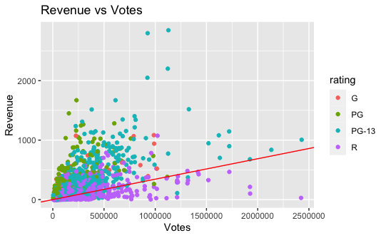

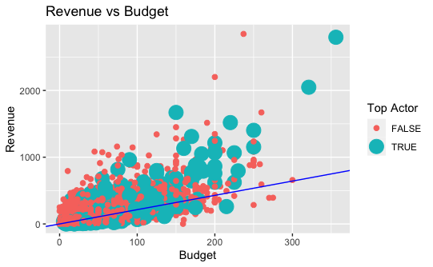

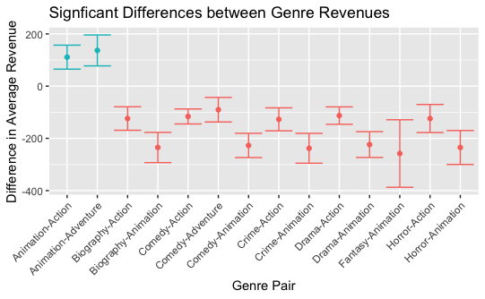

# CONCLUSION

In our analysis, we attempted to answer two questions relevant to what variables are the strongest indicators or predictors that go into making a popular movie. To further understand the concept of movie popularity, we chose two variables, the average of IMDB and TMDB score and the amount of revenue a film generates, to study the relationship that other factors have with these two variables. We combined two data sets and merged a third by creating a binary variable, and using it in tandem with our joined and cleaned original dataset. We explored the following variables in our analysis: budget, votes, genre, rating, top_10_director, top__100_actor, top_100_actress, year, runtime, title, month, and profit in relation to average IMDB/TMDB score and revenue generated. To answer our first question about which variable(s) are the best predictors of a strong average IMDB/TMDB score , we concluded that, although there are variables that work stronger in tandem with each other rather than when observed alone, our strongest categorical predictor was genre and our strongest numerical predictor was votes. When looking at variables that best worked together to give us a strong association, our visuals yielded votes, runtime, year, month, profit, genre, rating, and top 100 actors and actresses in accordance. For our second question regarding which variable(s) are the best predictors for the total revenue a movie produces, we came across the same answer of multiple variables being stronger predictors together, but the strongest categorical predictor was the binary top director and top 100 actors and actresses, and our strongest numerical predictor was budget. When looking at variables that best worked together to give us a strong association, our visuals yielded budget, votes, genre, rating, two binary variables indicating whether a director or actor was highly rated, avg_imdb_tmdb_score, and year.

These results are very relevant to modern society, with several real-life applications. For instance, it can be used by movie production companies to estimate the potential success of their upcoming movies based on the significant variables identified in the dataset such as budget, genre, votes, inclusion of a top director, and inclusion of top actor. This information can help production companies make more informed decisions on which movies to produce, what directors to hire, and what actors to cast. The analysis can also be used by movie distributors to determine which movies to purchase for distribution and how to market them to the target audience. Additionally, it can be useful for investors who are interested in funding movie productions as it provides insight into the potential return on investment. Overall, the data analysis project provides valuable insights into the movie industry and can be used to inform decision-making processes for various stakeholders.

An aspect that we could have improved on that would yield more accurate results would be testing our model on novel data. This would help us see the accuracy of our model, and any ways that we could possibly improve it. While exploring the binary variable of top 100 actors and actresses, as well as top 10 directors, there could have been a flaw in our dataset as our top 10 directors were based off of box office whereas our top 100 actors and actresses were directly from IMDB, which may have resulted in a stronger correlation with revenue generated by a movie. The prediction model we created could assist producers in examining which variables we found were strongest associated with generating high amounts of revenue as well as strong IMDB or TMDB scores. Knowing these factors would provide beneficial for the film industry as a whole to grow and [succeed].